# Poject #1 - Classification Class in social networks

Viet Ba Mai, Klaudia Magda

November 6th, 2016

# Introduction

The goal of this project is to predict the number of shares in social networks using the *Online News Popularity* dataset from UCI. In this report we will implement several classifiers on preprocessed set using variables selected with the help of filters and compare their performance in order to find the best one.

# Libraries used

```r
library(e1071)
library(caret)
library(magrittr)
library(plyr)
library(dplyr)
library(corrplot)
library(randomForest)
library(pROC)
library(Epi)
library(nnet)
library(party)
library(rpart)
```

# Data preparation

## Target variable

The target variable of the set is `shares`. The first thing one can notice is that it contains almost 1500 distinct values, where more of them occur only once. This means that this variable has a very high variance and trying to train the classifiers with it would yield very inaccurate result. More than that the feature selection function we will use in the next sections are unable to handle such a big number of classes.

Our solution to this problem was to create a new target variable with only a few classes representing the ranges of shares.

```r
data <- read.csv(file.path(file.path(getwd(), "OnlineNewsPopularity"), "OnlineNewsPopularity.csv"), header=TRUE, sep=",", encoding="UTF-8")
sum(!complete.cases(data))
```

```
## [1] 1
```

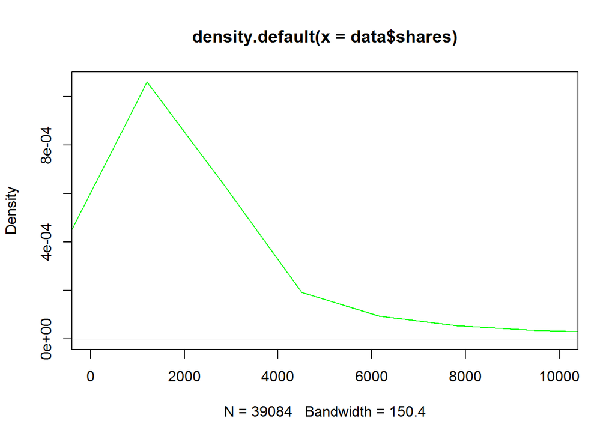

```r
#Removing rows with NaN
data <- data[complete.cases(data),]
plot(density(data$shares), xlim=c(0,10000), col="green")
```

```r
categories = cut(data$shares, c(0, 1000, 2000, Inf))
data$Class = as.numeric(categories)
data$Class = factor(data$Class)
length(levels(data$Class))
```

```
## [1] 3
```

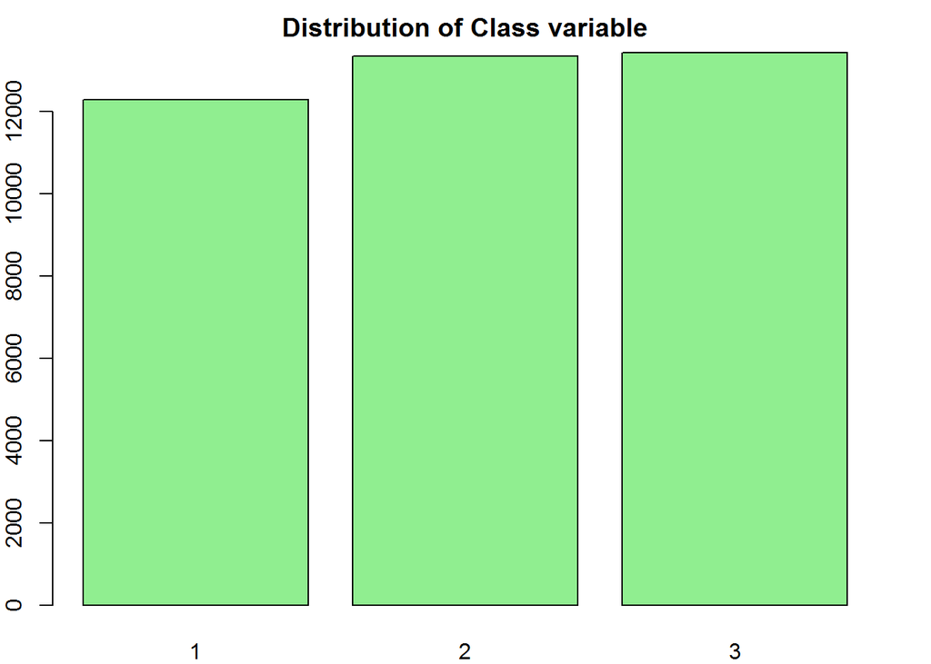

```r
par(mar = rep(2, 4))
barplot(table(data$Class), col="lightgreen", main="Distribution of Class variable")
```

```r
prop.table(table(data$Class))
```

```
##
##         1         2         3
## 0.3146812 0.3416232 0.3436956
```

## Preprocessing

In order to make working with the data easier we immediatelly dropped the original target variable `shares` as well as non-predictive columns `url`, `timedelta` and `shares` and then removed near zero variance and highly correlated variables.

```r
data <- subset(data, select = -c(url, timedelta, shares))

#Removing near zero variance variables
nzv <- nearZeroVar(data)
names(data)[nzv]
```

```
## [1] "n_non_stop_words" "kw_min_max"
```

```r
#Normalisation
preProcValues <- preProcess(data, method = c("range"))
dataNorm <- predict(preProcValues, data)
#Removing highly correlated variables
d.num <- dataNorm %>% select(which(sapply(dataNorm, is.numeric)))
too_high <- findCorrelation(cor(d.num), cutoff = 0.725, verbose = FALSE)
names(d.num)[too_high]
```

```
##  [1] "rate_positive_words"       "kw_avg_avg"
##  [3] "data_channel_is_world"     "min_negative_polarity"
##  [5] "rate_negative_words"       "LDA_04"
##  [7] "LDA_00"                    "kw_max_max"
##  [9] "self_reference_max_shares" "kw_max_min"
## [11] "self_reference_min_shares" "n_unique_tokens"
## [13] "n_non_stop_words"
```

```r
data = dataNorm[,-c(too_high)]
```

# Feature selection

After data preparation we were still left with over 40 predictors. In order to choose only the best ones for classification we decided to use a `filter` method - Selection by filter (`sbf`) on a smaller sample of the dataset.

```r
size <- floor(0.05 * nrow(data))
indxSample <- sample(seq_len(nrow(data)), size = size)
sample <- data[indxSample, ]
length(levels(sample$Class))
```

```
## [1] 3
```

```r
#SBF
filterCtrl <- sbfControl(functions = rfSBF, method = "repeatedcv", verbose = FALSE, repeats = 5)
rfWithFilter <- sbf(form = Class ~ ., data = sample, sbfControl = filterCtrl, allowParallel = TRUE, variables=TRUE)
rfWithFilter
```

```
##
## Selection By Filter
##
## Outer resampling method: Cross-Validated (10 fold, repeated 5 times)
##
## Resampling performance:
##
##  Accuracy  Kappa AccuracySD KappaSD
##    0.4686 0.2031    0.03606 0.05419
##
## Using the training set, 26 variables were selected:
##    n_tokens_content, num_hrefs, num_imgs, num_keywords, data_channel_is_lifestyle...
##
## During resampling, the top 5 selected variables (out of a possible 31):
##    avg_positive_polarity (100%), data_channel_is_entertainment (100%), data_channel_is_lifestyle (100%), data_channel_is_socmed (100%), data_channel_is_tech (100%)
##
## On average, 26.3 variables were selected (min = 25, max = 29)
```

```r
selections <- rfWithFilter$variables$selectedVars
selections <- append(selections, "Class")
selections
```

```
##  [1] "n_tokens_content"              "num_hrefs"
##  [3] "num_imgs"                      "num_keywords"
##  [5] "data_channel_is_lifestyle"     "data_channel_is_entertainment"
##  [7] "data_channel_is_socmed"        "data_channel_is_tech"
##  [9] "kw_min_min"                    "kw_min_avg"
## [11] "kw_max_avg"                    "self_reference_avg_sharess"
## [13] "weekday_is_tuesday"            "weekday_is_wednesday"
## [15] "weekday_is_saturday"           "weekday_is_sunday"
## [17] "is_weekend"                    "LDA_01"
## [19] "LDA_02"                        "LDA_03"
## [21] "global_subjectivity"           "global_sentiment_polarity"
## [23] "global_rate_positive_words"    "avg_positive_polarity"
## [25] "max_positive_polarity"         "title_sentiment_polarity"
## [27] "Class"
```

### SBF result analysis

From the correlation plot we can see by the colour and the size of circles that the selected variables are not highly correlated which makes them good candidates for predictors.

```r
subdata <- data[selections]
head(subdata)
```

```
##   n_tokens_content  num_hrefs  num_imgs num_keywords
## 1       0.02584376 0.02139037 0.0078125    0.4444444
## 2       0.03009205 0.01604278 0.0078125    0.3333333
## 3       0.02489969 0.01604278 0.0078125    0.5555556
## 4       0.06266226 0.04812834 0.0078125    0.6666667
## 5       0.12650460 0.10160428 0.1562500    0.6666667
## 6       0.04366297 0.01069519 0.0000000    0.8888889
##   data_channel_is_lifestyle data_channel_is_entertainment
## 1                         0                             1
## 2                         0                             0
## 3                         0                             0
## 4                         0                             1
## 5                         0                             0
## 6                         0                             0
##   data_channel_is_socmed data_channel_is_tech  kw_min_min   kw_min_avg
```

[output cut: 48 more lines]

```r
summary(subdata)
```

```
##  n_tokens_content    num_hrefs          num_imgs         num_keywords
##  Min.   :0.00000   Min.   :0.00000   Min.   :0.000000   Min.   :0.0000
##  1st Qu.:0.02903   1st Qu.:0.02139   1st Qu.:0.007812   1st Qu.:0.5556
##  Median :0.04827   Median :0.04278   Median :0.007812   Median :0.6667
##  Mean   :0.06454   Mean   :0.05823   Mean   :0.035658   Mean   :0.6920
##  3rd Qu.:0.08449   3rd Qu.:0.07487   3rd Qu.:0.031250   3rd Qu.:0.8889
##  Max.   :1.00000   Max.   :1.00000   Max.   :1.000000   Max.   :1.0000
##  data_channel_is_lifestyle data_channel_is_entertainment
##  Min.   :0.00000           Min.   :0.0000
##  1st Qu.:0.00000           1st Qu.:0.0000
##  Median :0.00000           Median :0.0000
##  Mean   :0.05289           Mean   :0.1786
##  3rd Qu.:0.00000           3rd Qu.:0.0000
##  Max.   :1.00000           Max.   :1.0000
##  data_channel_is_socmed data_channel_is_tech   kw_min_min
##  Min.   :0.00000        Min.   :0.0000       Min.   :0.00000
##  1st Qu.:0.00000        1st Qu.:0.0000       1st Qu.:0.00000
##  Median :0.00000        Median :0.0000       Median :0.00000
##  Mean   :0.05903        Mean   :0.1864       Mean   :0.07274
##  3rd Qu.:0.00000        3rd Qu.:0.0000       3rd Qu.:0.01323
##  Max.   :1.00000        Max.   :1.0000       Max.   :1.00000
##    kw_min_avg          kw_max_avg      self_reference_avg_sharess
##  Min.   :0.0000000   Min.   :0.00000   Min.   :0.000000
##  1st Qu.:0.0002767   1st Qu.:0.01194   1st Qu.:0.001168
##  Median :0.2822524   Median :0.01460   Median :0.002609
##  Mean   :0.3086795   Mean   :0.01897   Mean   :0.007642
##  3rd Qu.:0.5687903   3rd Qu.:0.02017   3rd Qu.:0.006166
##  Max.   :1.0000000   Max.   :1.00000   Max.   :1.000000
##  weekday_is_tuesday weekday_is_wednesday weekday_is_saturday
##  Min.   :0.0000     Min.   :0.0000       Min.   :0.00000
##  1st Qu.:0.0000     1st Qu.:0.0000       1st Qu.:0.00000
##  Median :0.0000     Median :0.0000       Median :0.00000
##  Mean   :0.1861     Mean   :0.1887       Mean   :0.06156
##  3rd Qu.:0.0000     3rd Qu.:0.0000       3rd Qu.:0.00000
##  Max.   :1.0000     Max.   :1.0000       Max.   :1.00000
##  weekday_is_sunday   is_weekend         LDA_01            LDA_02
##  Min.   :0.00000   Min.   :0.0000   Min.   :0.00000   Min.   :0.00000
##  1st Qu.:0.00000   1st Qu.:0.0000   1st Qu.:0.02701   1st Qu.:0.03106
##  Median :0.00000   Median :0.0000   Median :0.03601   Median :0.04348
##  Mean   :0.06875   Mean   :0.1303   Mean   :0.15258   Mean   :0.23375
```

[output cut: 8 more lines]

```
##  Max.   :1.00000   Max.   :1.0000      Max.   :1.0000
##  global_rate_positive_words avg_positive_polarity max_positive_polarity
##  Min.   :0.0000             Min.   :0.0000        Min.   :0.000
##  1st Qu.:0.1838             1st Qu.:0.3067        1st Qu.:0.600
##  Median :0.2516             Median :0.3591        Median :0.800
##  Mean   :0.2557             Mean   :0.3545        Mean   :0.758
##  3rd Qu.:0.3241             3rd Qu.:0.4117        3rd Qu.:1.000
##  Max.   :1.0000             Max.   :1.0000        Max.   :1.000
##  title_sentiment_polarity Class
##  Min.   :0.0000           1:12299
##  1st Qu.:0.5000           2:13352
##  Median :0.5000           3:13433
##  Mean   :0.5358
##  3rd Qu.:0.5750
##  Max.   :1.0000
```

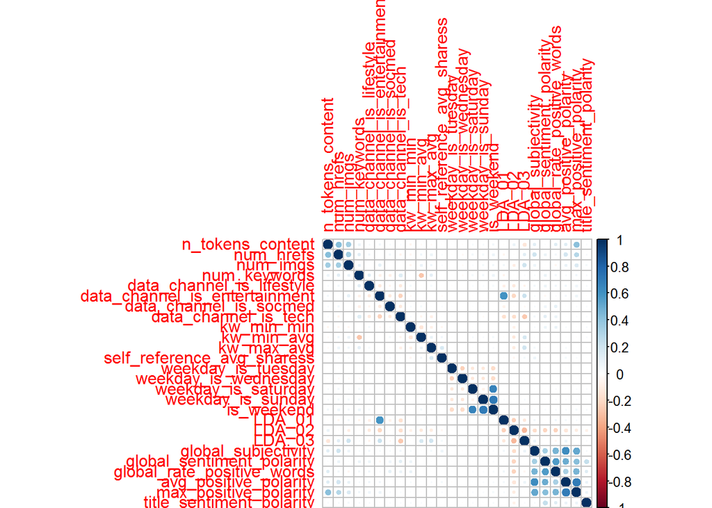

```r
sub.num <- subdata %>% select(which(sapply(subdata, is.numeric)))
corrplot(cor(sub.num), method="circle")
```

## Data Analysis

In this section 3 `pairs` plots and 3 scatter plots are presented to help us understand the given data. `Pairs` plot is a matrix of `scatter` plots which show relations between two variables. We decided to analyse 15 of them in 3 parts.

When the data has a line shape it means that the analysed data is of both continuous and categorical type. On the other hand when the shape is of singular dots in the corners it means that we are dealing with two categorical variables. Otherwise, when the markers are spread on a plane - two continuous features are analysed.

From the plots we can see that almost half of our features are discrete.

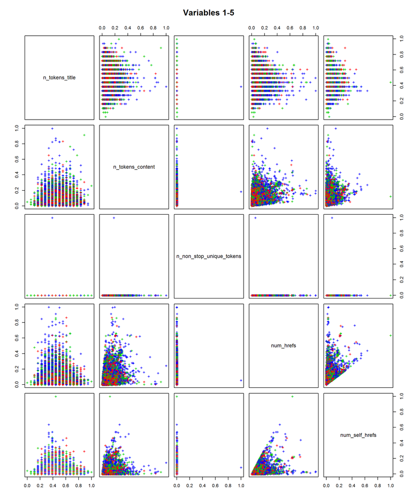

```r
 pairs(data[,1:5], main = "Variables 1-5", pch = "+", col = c("red", "green3",  "blue")[unclass(data$Class)])
```

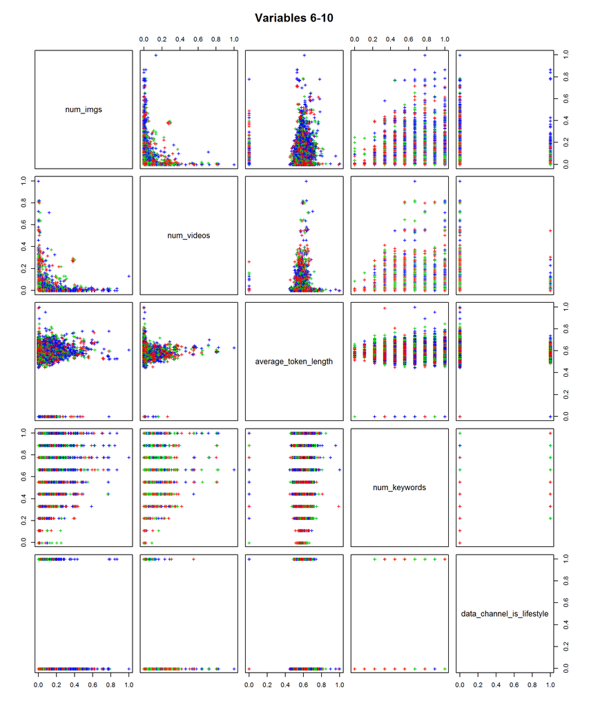

```r
 pairs(data[,6:10], main = "Variables 6-10",
 pch = "+", col = c("red", "green3",  "blue")[unclass(data$Class)])
```

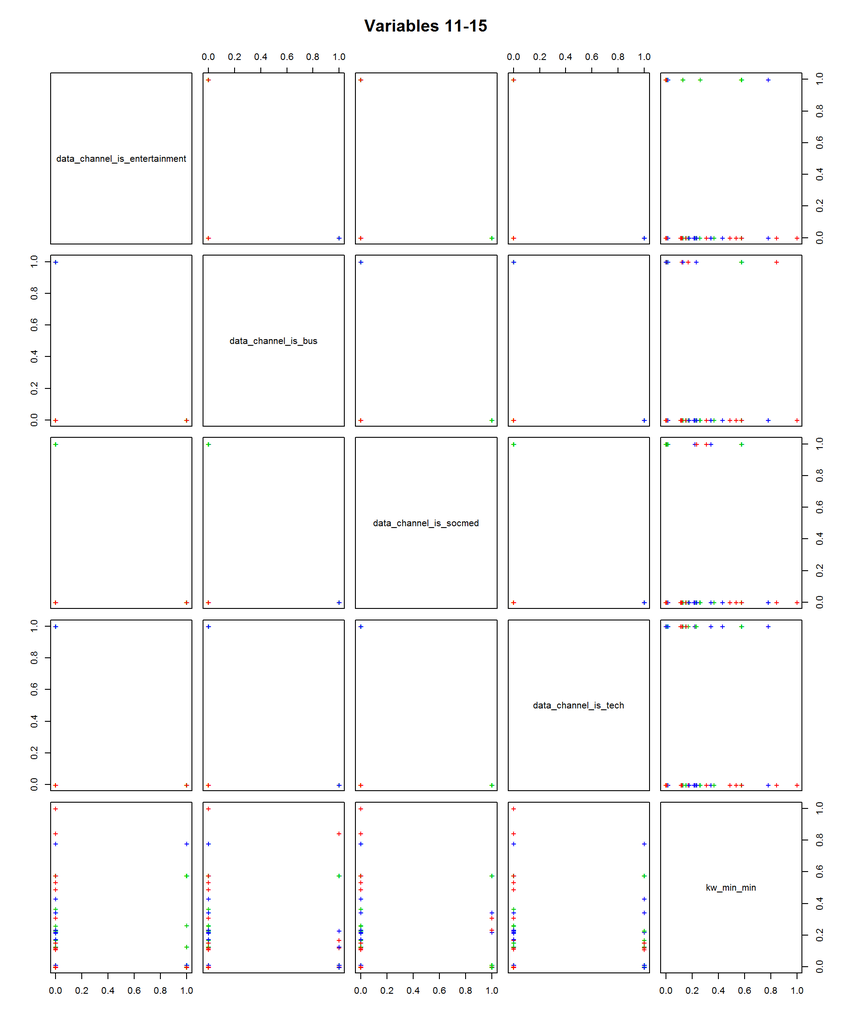

```r
pairs(data[,11:15], main = "Variables 11-15",
pch = "+", col = c("red", "green3",  "blue")[unclass(data$Class)])
```

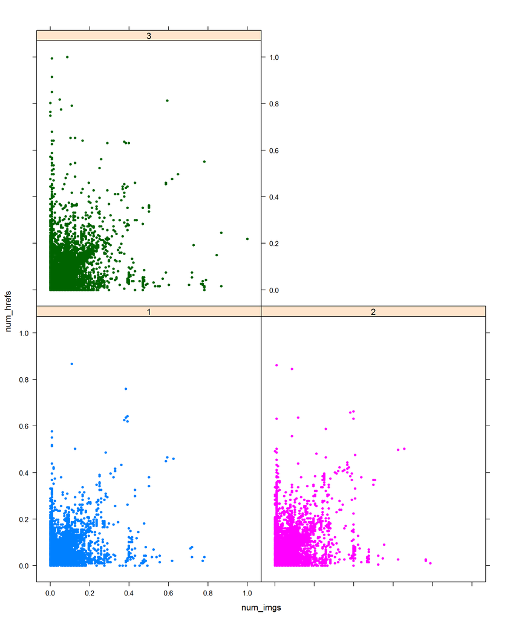

```r
xyplot(num_hrefs ~ num_imgs | Class, data, groups = data$Class, pch= 20)
```

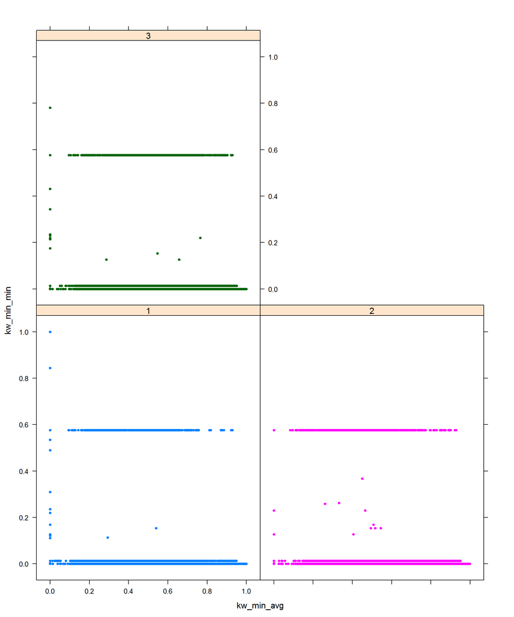

```r
xyplot(kw_min_min ~ kw_min_avg | Class, data, groups = data$Class, pch= 20)
```

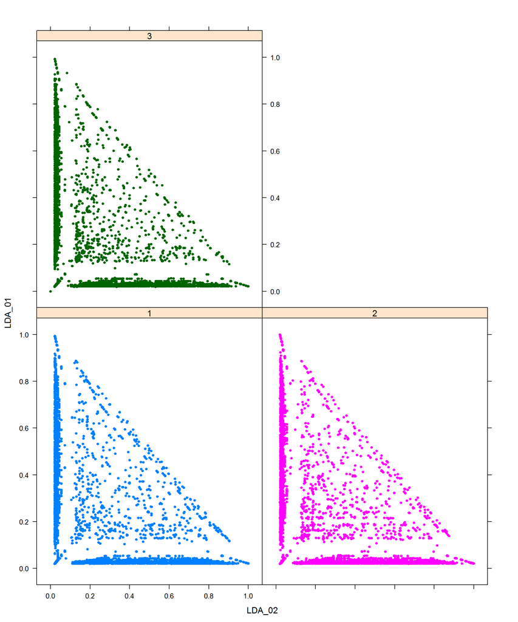

```r
xyplot(LDA_01 ~ LDA_02 |Class, data, groups = data$Class, pch= 20)
```

# Data splitting

Having the data prepared for classification we need to divide it into a training and testing set. We chose the size of the training set to be 0.75 of the original data set.

```r
set.seed(1313)
size <- floor(0.75 * nrow(subdata))
indxTrain <- sample(seq_len(nrow(subdata)), size = size)

dataTrain <- subdata[indxTrain, ]
dataTest <- subdata[-indxTrain, ]
```

# Classifiers

## Random Forest

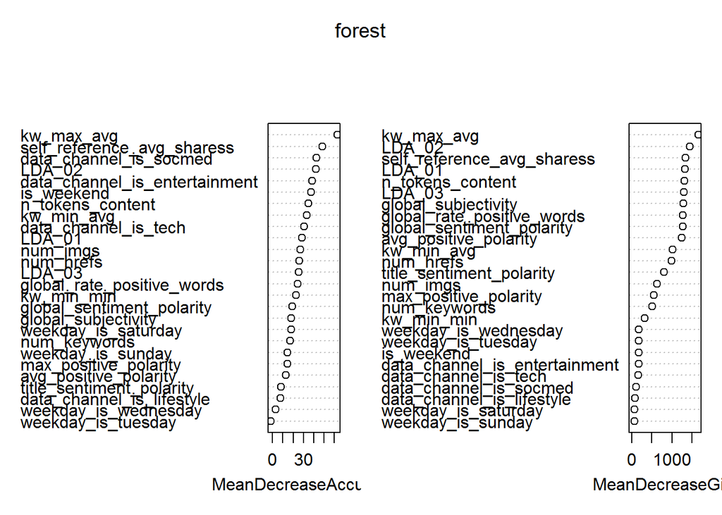

```r
forest <- randomForest(Class ~ ., data = dataTrain, importance = TRUE, na.action = na.omit)
varImpPlot(forest)
```

```r
importance(forest)
```

```
##                                        1          2           3
## n_tokens_content              27.9524880  0.6317911 23.86761510
## num_hrefs                     24.8307475 -1.0558040 16.48794677
## num_imgs                      33.1903497  2.1631820  6.79004119
## num_keywords                  13.2482205 -0.4166744 11.10967271
## data_channel_is_lifestyle     15.3386733  1.4215942 -7.78015154
## data_channel_is_entertainment 32.6412354  7.1556284 21.84816061
## data_channel_is_socmed        25.4396450  9.8676523 38.39114832
## data_channel_is_tech          26.7620980  3.4471961 20.31249636
## kw_min_min                    13.0035140  6.8839836 18.45868567
## kw_min_avg                    41.1000191 -4.4804746 14.61078665
## kw_max_avg                    43.7925887 -0.4358342 49.17049006
## self_reference_avg_sharess    48.6630260 -3.2391938 39.47841833
## weekday_is_tuesday            -0.1932411 -1.0066761 -1.87222046
## weekday_is_wednesday           4.0130042 -0.5330279  1.58340292
## weekday_is_saturday           20.1438122  0.7505396  4.47210422
## weekday_is_sunday             18.0730357  3.0038426  1.57413615
## is_weekend                    47.0747597  6.7181381 11.21505899
## LDA_01                        20.2205592  3.7915727 18.78902244
## LDA_02                        45.8609806 -6.3201285 22.81235318
## LDA_03                        22.5636771  1.0651554 13.77937432
## global_subjectivity            8.3352937  4.0304192 16.32386982
## global_sentiment_polarity     17.9345047  3.2733071 10.11804711
## global_rate_positive_words    24.0352775 -0.9240218 12.50235514
## avg_positive_polarity          4.3396862  2.3521823 13.05173568
## max_positive_polarity         11.8785343 -4.9964530 15.17325536
## title_sentiment_polarity      12.5434077  1.3814972 -0.01446559
##                               MeanDecreaseAccuracy MeanDecreaseGini
## n_tokens_content                         34.745436       1305.93406
## num_hrefs                                25.868760        990.44758
## num_imgs                                 27.037033        631.85563
## num_keywords                             17.050742        508.15952
## data_channel_is_lifestyle                 7.784331         76.83975
## data_channel_is_entertainment            38.705477        168.63589
## data_channel_is_socmed                   43.082621        110.79296
## data_channel_is_tech                     30.765108        153.25579
## kw_min_min                               22.624128        324.50989
## kw_min_avg                               33.533088       1019.32518
## kw_max_avg                               63.372042       1657.88591
## self_reference_avg_sharess               48.793249       1336.29169
## weekday_is_tuesday                       -1.760955        173.54069
## weekday_is_wednesday                      2.974767        174.69738
## weekday_is_saturday                      18.107585         70.17990
## weekday_is_sunday                        14.675620         66.82468
## is_weekend                               37.416244        172.97206
## LDA_01                                   28.442611       1322.26025
## LDA_02                                   42.341250       1435.82752
## LDA_03                                   25.705945       1301.13779
## global_subjectivity                      18.397602       1284.54798
## global_sentiment_polarity                19.229896       1266.38486
## global_rate_positive_words               24.673584       1271.31055
## avg_positive_polarity                    13.077393       1243.52744
## max_positive_polarity                    14.593045        546.76091
## title_sentiment_polarity                  8.380652        802.76246
```

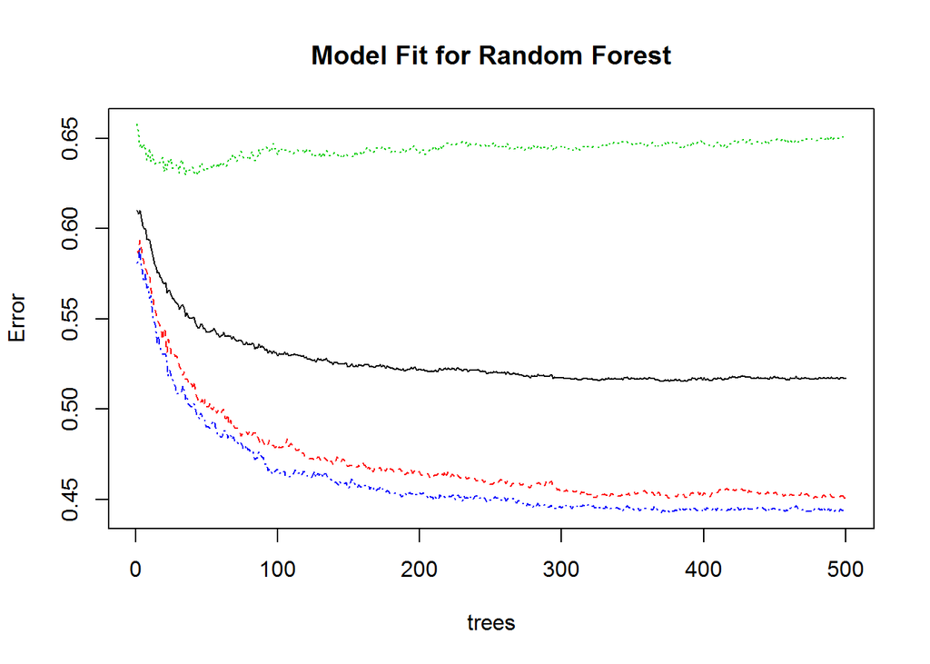

```r
predForest = predict(forest, dataTest, type="class")
plot(forest, main="Model Fit for Random Forest")
```

```r
forestTab <- table(true = dataTest$Class, predicted = predForest)
rfAcc <- sum(diag(forestTab)) / sum(forestTab)
rfAcc
```

```
## [1] 0.4859277
```

### Top variables by importance

```r
sortedImportance=order(-forest$importance[,5])
tops=rownames(forest$importance)[sortedImportance][1:15][1:15]
tops <- append(tops, "Class")
subTrain <- dataTrain[tops]
subTest <- dataTest[tops]
forestTop <- randomForest(Class ~ ., data = subTrain, na.action = na.omit)
predTopForest = predict(forestTop, subTest)
forestTopTab <- table(true = subTest$Class, predicted = predTopForest)
rfTopAcc <- sum(diag(forestTopTab)) / sum(forestTopTab)
rfTopAcc
```

[output not shown]

The accuracy is very similar to the random forest working on more features hence for the remaining classifiers we will use only the 15 features selected by importance.

## Tree

Tree is undirected graph with nodes and leaf nodes that can indicate the value of Class.

```r
tree<-ctree(Class ~ ., data=subTrain)
predTree = predict(tree, subTest)
treeTab <- table(true = subTest$Class, predicted = predTree)
treeAcc <- sum(diag(treeTab)) / sum(treeTab)
treeAcc
```

```
## [1] 0.4375192
```

## Nearest Neighbours

This is a non-parametric method which input has `k` nearest examples from the training set in the space of numerical features.

```r
#Finding optimal k
tuneK <- 1:50
performance <- sapply(tuneK, function(k) {
  knnFit <- knn3(Class ~ ., data = subTrain, k=k)
  tab <- table(true = subTest$Class,
          predict = predict(knnFit, subTest, type="class"))
  sum(diag(tab)) / sum(tab)
})

optimal_k = which.max(performance)
optimal_k
```

```
## [1] 48
```

```r
performance[optimal_k]
```

```
## [1] 0.4304575
```

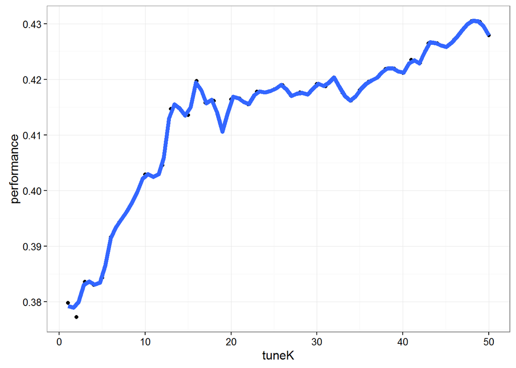

```r
df <- data.frame(tuneK, performance)

ggplot(df, aes(tuneK, performance)) +
  geom_point() +
  geom_smooth(se=FALSE, span=0.1, size=2) +
  theme_bw()
```

```r
###Applying optimal k
knnFit <- knn3(Class ~ ., data = subTrain, k=optimal_k)
predKnn <- predict(knnFit, subTest, type="class")
tab_optimal <- table(true = subTest$Class, predicted = predKnn)
knnAcc <- sum(diag(tab_optimal)) / sum(tab_optimal)
knnAcc
```

```
## [1] 0.4298434
```

## Super Vector Machines

`SVM` classifier shows each data item on a n-dimensional plane, where `n` is the quantity of features (and their values being a particular coordinate) used and then performs classification to distinguish the classes on a plane. It produces support vectors for each class. We decided to use `SimonsSVM` library, because it allows options for using cells and threads number which decrease the execution time.

```r
svm<-SimonsSVM::svm(Class ~ ., subTrain, useCells=TRUE, threads=3)
predSVM = predict(svm, subTest, type="class")
svmTab <- table(true = subTest$Class, predicted = predSVM)
svmAcc <- sum(diag(svmTab)) / sum(svmTab)
svmAcc
```

```
## [1] 0.4307645
```

## Multinomial Logistic Regression

Logistic regression, also referred to as `logit model` is a predictive analysis.

Since we have more than two classes it is necessary to use the `multinomial logistic regression` rather than the basic binomial one. We will use the `multinom()` function from `nnet` library.

```r
vglm <- multinom(Class ~ ., data=subTrain)
predVglm = predict(vglm, subTest, type="class")
vglmTab <- table(true = subTest$Class, predicted = predVglm)
vglmAcc <- sum(diag(vglmTab)) / sum(vglmTab)
vglmAcc
```

```
## [1] 0.4300481
```

## Naive Bayes

`Naive Bayes` is a classifier that uses prior probability, to make a prediction. It is called ‘naive’, because it simplifies the calculation of probabilities by assuming that each attribute belonging to a given class value is independent.

```r
bayes <- naiveBayes(Class ~ ., data = subTrain)
predBayes = predict(bayes, subTest, type="class")
bayesTab <- table(true = subTest$Class, predicted = predBayes)
bayesAcc <- sum(diag(bayesTab)) / sum(bayesTab)
bayesAcc
```

```
## [1] 0.393102
```

# Performance

We will check the performance of used classifiers with `confusion matrix`, Area Under Curve (`AUC`) and `Macro Averaged Metrics`.

## Confusion Matrix

Confusion matrix is a table describing performance of classifiers. Besides, `confusionMatrix()` function also provides additional statistics.

```r
#Random Forest
rfConfusionMatrix <- confusionMatrix(predForest, subTest$Class)
rfConfusionMatrix
```

```
## Confusion Matrix and Statistics
##
##           Reference
## Prediction    1    2    3
##          1 1665 1012  572
##          2  809 1138  848
##          3  635 1147 1945
##
## Overall Statistics
##
##                Accuracy : 0.4859
##                  95% CI : (0.476, 0.4959)
##     No Information Rate : 0.3444
##     P-Value [Acc > NIR] : < 2.2e-16
##
##                   Kappa : 0.2285
##  Mcnemar's Test P-Value : 2.977e-15
##
## Statistics by Class:
##
##                      Class: 1 Class: 2 Class: 3
## Sensitivity            0.5355   0.3452   0.5780
## Specificity            0.7622   0.7441   0.7218
## Pos Pred Value         0.5125   0.4072   0.5219
## Neg Pred Value         0.7786   0.6905   0.7651
## Prevalence             0.3182   0.3374   0.3444
## Detection Rate         0.1704   0.1165   0.1991
## Detection Prevalence   0.3325   0.2861   0.3814
## Balanced Accuracy      0.6489   0.5446   0.6499
```

```r
#Forest - Top variables by importance
forestTopConfusionMatrix <- confusionMatrix(predTopForest, subTest$Class)
forestTopConfusionMatrix
```

```
## Confusion Matrix and Statistics
##
##           Reference
## Prediction    1    2    3
##          1 1490  979  551
##          2  884 1145  901
##          3  735 1173 1913
##
## Overall Statistics
##
##                Accuracy : 0.4655
##                  95% CI : (0.4555, 0.4754)
##     No Information Rate : 0.3444
##     P-Value [Acc > NIR] : < 2.2e-16
##
##                   Kappa : 0.1971
##  Mcnemar's Test P-Value : 2.023e-14
##
## Statistics by Class:
##
##                      Class: 1 Class: 2 Class: 3
## Sensitivity            0.4793   0.3473   0.5685
## Specificity            0.7703   0.7243   0.7022
## Pos Pred Value         0.4934   0.3908   0.5007
## Neg Pred Value         0.7602   0.6854   0.7560
## Prevalence             0.3182   0.3374   0.3444
## Detection Rate         0.1525   0.1172   0.1958
## Detection Prevalence   0.3091   0.2999   0.3911
## Balanced Accuracy      0.6248   0.5358   0.6353
```

```r
#Tree
treeConfusionMatrix <- confusionMatrix(predTree, subTest$Class)
treeConfusionMatrix
```

```
## Confusion Matrix and Statistics
##
##           Reference
## Prediction    1    2    3
##          1 1511 1153  754
##          2  624  754  601
##          3  974 1390 2010
##
## Overall Statistics
##
##                Accuracy : 0.4375
##                  95% CI : (0.4277, 0.4474)
##     No Information Rate : 0.3444
##     P-Value [Acc > NIR] : < 2.2e-16
##
##                   Kappa : 0.1557
##  Mcnemar's Test P-Value : < 2.2e-16
##
## Statistics by Class:
##
##                      Class: 1 Class: 2 Class: 3
## Sensitivity            0.4860  0.22869   0.5973
## Specificity            0.7137  0.81078   0.6310
## Pos Pred Value         0.4421  0.38100   0.4595
## Neg Pred Value         0.7485  0.67364   0.7489
## Prevalence             0.3182  0.33743   0.3444
## Detection Rate         0.1546  0.07717   0.2057
## Detection Prevalence   0.3498  0.20254   0.4477
## Balanced Accuracy      0.5999  0.51974   0.6141
```

```r
#Nearest Neighbours
knnConfusionMatrix <- confusionMatrix(predKnn, subTest$Class)
knnConfusionMatrix
```

```
## Confusion Matrix and Statistics
##
##           Reference
## Prediction    1    2    3
##          1 1436 1084  776
##          2  862 1053  878
##          3  811 1160 1711
##
## Overall Statistics
##
##                Accuracy : 0.4298
##                  95% CI : (0.42, 0.4397)
##     No Information Rate : 0.3444
##     P-Value [Acc > NIR] : < 2.2e-16
##
##                   Kappa : 0.1445
##  Mcnemar's Test P-Value : 4.732e-14
##
## Statistics by Class:
##
##                      Class: 1 Class: 2 Class: 3
## Sensitivity            0.4619   0.3194   0.5085
## Specificity            0.7208   0.7312   0.6923
## Pos Pred Value         0.4357   0.3770   0.4647
## Neg Pred Value         0.7416   0.6784   0.7284
## Prevalence             0.3182   0.3374   0.3444
## Detection Rate         0.1470   0.1078   0.1751
## Detection Prevalence   0.3373   0.2858   0.3768
## Balanced Accuracy      0.5913   0.5253   0.6004
```

```r
#SVM
svmConfusionMatrix <- confusionMatrix(predSVM, subTest$Class)
svmConfusionMatrix
```

```
## Confusion Matrix and Statistics
##
##           Reference
## Prediction    1    2    3
##          1 1508 1154  788
##          2  873 1025  901
##          3  728 1118 1676
##
## Overall Statistics
##
##                Accuracy : 0.4308
##                  95% CI : (0.4209, 0.4407)
##     No Information Rate : 0.3444
##     P-Value [Acc > NIR] : < 2.2e-16
##
##                   Kappa : 0.1464
##  Mcnemar's Test P-Value : 5.953e-14
##
## Statistics by Class:
##
##                      Class: 1 Class: 2 Class: 3
## Sensitivity            0.4850   0.3109   0.4981
## Specificity            0.7085   0.7260   0.7118
## Pos Pred Value         0.4371   0.3662   0.4759
## Neg Pred Value         0.7467   0.6741   0.7297
## Prevalence             0.3182   0.3374   0.3444
## Detection Rate         0.1543   0.1049   0.1715
## Detection Prevalence   0.3531   0.2865   0.3605
## Balanced Accuracy      0.5968   0.5184   0.6050
```

```r
#Multinomial Logistic Regression
mlrConfusionMatrix <- confusionMatrix(predVglm, subTest$Class)
mlrConfusionMatrix
```

```
## Confusion Matrix and Statistics
##
##           Reference
## Prediction    1    2    3
##          1 1481 1115  779
##          2  736  892  757
##          3  892 1290 1829
##
## Overall Statistics
##
##                Accuracy : 0.43
##                  95% CI : (0.4202, 0.4399)
##     No Information Rate : 0.3444
##     P-Value [Acc > NIR] : < 2.2e-16
##
##                   Kappa : 0.1447
##  Mcnemar's Test P-Value : < 2.2e-16
##
## Statistics by Class:
##
##                      Class: 1 Class: 2 Class: 3
## Sensitivity            0.4764  0.27055   0.5435
## Specificity            0.7157  0.76939   0.6594
## Pos Pred Value         0.4388  0.37400   0.4560
## Neg Pred Value         0.7455  0.67438   0.7333
## Prevalence             0.3182  0.33743   0.3444
## Detection Rate         0.1516  0.09129   0.1872
## Detection Prevalence   0.3454  0.24409   0.4105
## Balanced Accuracy      0.5960  0.51997   0.6015
```

```r
#Naive Bayes
bayesConfusionMatrix <- confusionMatrix(predBayes, subTest$Class)
bayesConfusionMatrix
```

```
## Confusion Matrix and Statistics
##
##           Reference
## Prediction    1    2    3
##          1 2271 2102 1623
##          2  267  466  638
##          3  571  729 1104
##
## Overall Statistics
##
##                Accuracy : 0.3931
##                  95% CI : (0.3834, 0.4029)
##     No Information Rate : 0.3444
##     P-Value [Acc > NIR] : < 2.2e-16
##
##                   Kappa : 0.0978
##  Mcnemar's Test P-Value : < 2.2e-16
##
## Statistics by Class:
##
##                      Class: 1 Class: 2 Class: 3
## Sensitivity            0.7305  0.14134   0.3281
## Specificity            0.4409  0.86021   0.7971
## Pos Pred Value         0.3788  0.33990   0.4592
## Neg Pred Value         0.7780  0.66298   0.6931
## Prevalence             0.3182  0.33743   0.3444
## Detection Rate         0.2324  0.04769   0.1130
## Detection Prevalence   0.6137  0.14031   0.2460
## Balanced Accuracy      0.5857  0.50078   0.5626
```

## Area Under Curve

Receiver Operating Characteristics curve (`ROC`) visualises the performance of a classifier. `AUC` is the Area Under the ROC Curve, where the value equal to 1 means a perfect test.

```
##
## Call:
## plot.roc.default(x = predForest, predictor = as.numeric(subTest$Class))
##
## Data: as.numeric(subTest$Class) in 3249 controls (predForest 1) < 2795 cases (predForest 2).
## Area under the curve: 0.6229
```

```
##
## Call:
## plot.roc.default(x = predTopForest, predictor = as.numeric(subTest$Class))
##
## Data: as.numeric(subTest$Class) in 3020 controls (predTopForest 1) < 2930 cases (predTopForest 2).
## Area under the curve: 0.61
```

```
##
## Call:
## plot.roc.default(x = predTree, predictor = as.numeric(subTest$Class))
##
## Data: as.numeric(subTest$Class) in 3418 controls (predTree 1) < 1979 cases (predTree 2).
## Area under the curve: 0.5726
```

```
##
## Call:
## plot.roc.default(x = predKnn, predictor = as.numeric(subTest$Class))
##
## Data: as.numeric(subTest$Class) in 3296 controls (predKnn 1) < 2793 cases (predKnn 2).
## Area under the curve: 0.5708
```

```
##
## Call:
## plot.roc.default(x = predSVM, predictor = as.numeric(subTest$Class))
##
## Data: as.numeric(subTest$Class) in 3450 controls (predSVM 1) < 2799 cases (predSVM 2).
## Area under the curve: 0.5746
```

```
##
## Call:
## plot.roc.default(x = predVglm, predictor = as.numeric(subTest$Class))
##
## Data: as.numeric(subTest$Class) in 3375 controls (predVglm 1) < 2385 cases (predVglm 2).
## Area under the curve: 0.5744
```

```
##
## Call:
## plot.roc.default(x = predBayes, predictor = as.numeric(subTest$Class))
##
## Data: as.numeric(subTest$Class) in 5996 controls (predBayes 1) < 1371 cases (predBayes 2).
## Area under the curve: 0.6276
```

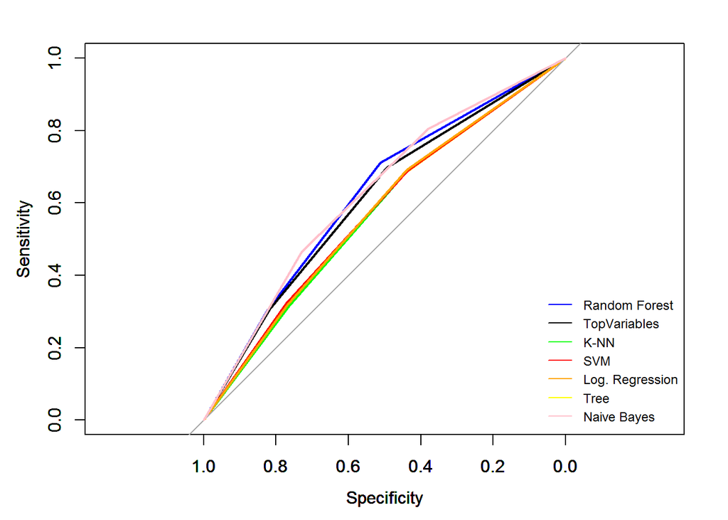

## Macro-Averaged Metrics

Tables for `In Macro-averaged Metrics` give an average of the following:

Precision shows how consistent are those evaluations - how many values were correctly estimated.

F1 is a harmonic mean of precision and recall. That is why has a very similar values like Precision and Recall and shows that those values are not various from each other.

```r
#RandomForest

forestPrec<-(diag(forestTab))/(colSums(forestTab))
forestRecall<-(diag(forestTab))/(rowSums(forestTab))
forestF1<-2*forestPrec*forestRecall/(forestPrec+forestRecall)

data.frame(forestPrec, forestRecall, forestF1)
```

```
##   forestPrec forestRecall  forestF1
## 1  0.5124654    0.5355420 0.5237496
## 2  0.4071556    0.3451623 0.3736047
## 3  0.5218675    0.5780089 0.5485054
```

```r
mForestPrec = mean(forestPrec)
mForestRecall = mean(forestRecall)
mForestF1 = mean(forestF1)
mamForest<-data.frame(mForestPrec, mForestRecall, mForestF1)
mamForest
```

```
##   mForestPrec mForestRecall mForestF1
## 1   0.4804962     0.4862377 0.4819532
```

```r
#TopForest

forestTopPrec<-(diag(forestTopTab))/(colSums(forestTopTab))
forestTopRecall<-(diag(forestTopTab))/(rowSums(forestTopTab))
forestTopF1<-2*forestTopPrec*forestTopRecall/(forestTopPrec+forestTopRecall)

data.frame(forestTopPrec, forestTopRecall, forestTopF1)
```

```
##   forestTopPrec forestTopRecall forestTopF1
## 1     0.4933775       0.4792538   0.4862131
## 2     0.3907850       0.3472854   0.3677533
## 3     0.5006543       0.5684993   0.5324242
```

```r
mForestTopPrec = mean(forestTopPrec)
mForestTopRecall = mean(forestTopRecall)
mForestTopF1 = mean(forestTopF1)
mamForestTop<-data.frame(mForestTopPrec, mForestTopRecall, mForestTopF1)
mamForestTop
```

```
##   mForestTopPrec mForestTopRecall mForestTopF1
## 1      0.4616056        0.4650128    0.4621302
```

```r
#Tree

treePrec<-(diag(treeTab))/(colSums(treeTab))
treeRecall<-(diag(treeTab))/(rowSums(treeTab))
treeF1<-2*treePrec*treeRecall/(treePrec+treeRecall)

data.frame(treePrec, treeRecall, treeF1)
```

```
##    treePrec treeRecall    treeF1
## 1 0.4420714  0.4860084 0.4629998
## 2 0.3810005  0.2286928 0.2858226
## 3 0.4595336  0.5973254 0.5194470
```

```r
mTreePrec = mean(treePrec)
mTreeRecall = mean(treeRecall)
mTreeF1 = mean(treeF1)
mamTree<-data.frame(mTreePrec, mTreeRecall, mTreeF1)
mamTree
```

```
##   mTreePrec mTreeRecall   mTreeF1
## 1 0.4275352   0.4373422 0.4227565
```

```r
#Nearest Neighbours

knnPrec<-(diag(tab_optimal))/(colSums(tab_optimal))
knnRecall<-(diag(tab_optimal))/(rowSums(tab_optimal))
knnF1<-2*knnPrec*knnRecall/(knnPrec+knnRecall)

data.frame(knnPrec, knnRecall, knnF1)
```

```
##     knnPrec knnRecall     knnF1
## 1 0.4356796 0.4618849 0.4483997
## 2 0.3770140 0.3193813 0.3458128
## 3 0.4646931 0.5084695 0.4855967
```

```r
mKnnPrec = mean(knnPrec)
mKnnRecall = mean(knnRecall)
mKnnF1 = mean(knnF1)
mamKnn<-data.frame(mKnnPrec, mKnnRecall, mKnnF1)
mamKnn
```

```
##    mKnnPrec mKnnRecall    mKnnF1
## 1 0.4257956  0.4299119 0.4266031
```

```r
#SVM

svmPrec<-(diag(svmTab))/(colSums(svmTab))
svmRecall<-(diag(svmTab))/(rowSums(svmTab))
svmF1<-2*svmPrec*svmRecall/(svmPrec+svmRecall)

data.frame(svmPrec, svmRecall, svmF1)
```

```
##     svmPrec svmRecall     svmF1
## 1 0.4371014 0.4850434 0.4598262
## 2 0.3662022 0.3108887 0.3362861
## 3 0.4758660 0.4980684 0.4867141
```

```r
mSvmPrec = mean(svmPrec)
mSvmRecall = mean(svmRecall)
mSvmF1 = mean(svmF1)
mamSvm<-data.frame(mSvmPrec, mSvmRecall, mSvmF1)
mamSvm
```

```
##    mSvmPrec mSvmRecall    mSvmF1
## 1 0.4263899  0.4313335 0.4276088
```

```r
#Multinomial Logistic Regression

vglmPrec<-(diag(vglmTab))/(colSums(vglmTab))
vglmRecall<-(diag(vglmTab))/(rowSums(vglmTab))
vglmF1<-2*vglmPrec*vglmRecall/(vglmPrec+vglmRecall)

data.frame(vglmPrec, vglmRecall, vglmF1)
```

```
##    vglmPrec vglmRecall    vglmF1
## 1 0.4388148  0.4763590 0.4568168
## 2 0.3740042  0.2705490 0.3139740
## 3 0.4559960  0.5435364 0.4959328
```

```r
mVglmPrec = mean(vglmPrec)
mVglmRecall = mean(vglmRecall)
mVglmF1 = mean(vglmF1)
mamVglm<-data.frame(mVglmPrec, mVglmRecall, mVglmF1)
mamVglm
```

```
##   mVglmPrec mVglmRecall   mVglmF1
## 1 0.4229383   0.4301481 0.4222412
```

```r
#Bayes

bayesPrec<-(diag(bayesTab))/(colSums(bayesTab))
bayesRecall<-(diag(bayesTab))/(rowSums(bayesTab))
bayesF1<-2*bayesPrec*bayesRecall/(bayesPrec+bayesRecall)

data.frame(bayesPrec, bayesRecall, bayesF1)
```

```
##   bayesPrec bayesRecall   bayesF1
## 1 0.3787525   0.7304600 0.4988468
## 2 0.3398979   0.1413406 0.1996572
## 3 0.4592346   0.3280832 0.3827353
```

```r
mBayesPrec = mean(bayesPrec)
mBayesRecall = mean(bayesRecall)
mBayesF1 = mean(bayesF1)
mamBayes<-data.frame(mBayesPrec, mBayesRecall, mBayesF1)
mamBayes
```

```
##   mBayesPrec mBayesRecall  mBayesF1
## 1  0.3926283    0.3999613 0.3604131
```

# Conclusions

[output not shown]

Our task was to find the best classification model for given data set and compare their performance with various methods hence we implemented 6 distinct classifiers. In the summary table above given are: `Accuracy`, `AUC`, `Precision`, `Recall` and `F1`.

We believe this is due to the fact that random forest uses multiple decision trees which makes it one of the most powerful classifiers and is thus more suitable for such complex data sets.

To have a better view on what would be an expected accuracy of this task we checked the public leaderboard of `Online News Popularity` competition on Kaggle (ttps://inclass.kaggle.com/c/predicting-online-news-popularity/leaderboard/public ). It is written that `0.39130` is the `Performance you can expect to achieve with a simple application of a nearest neighbor algorithm without any optimization whatsoever` as well as `0.21739` being `The lowest possible performance you should be able to achieve, based on randomly sampling from a set of 5 classes` for a random classification.

In the first phase of the project we implemented a binary classification (for shares below 1400 or otherwise) with a higher result of `58%`. On the other hand this phase shows a multiclass classification with 3, balanced classes. After some experiments we found that the less balanced distribution of classes, the lower results we obtain (dropping even below `40%`) hence our decision to split the shares as evenly as possible.

In conclusion, both the binary and multiclass classification experiments showed that Random Forest yields the highest results thus is is the best classifier we tested.